# Lab 4: Data Cleaning for Final Projects

Author

Your Name Here

Published

March 25, 2026

## Overview

In this lab you will build a cleaned, analysis-ready dataset from the raw `attain.csv` file — showing you the major steps you will use to clean the dataset that you will use for your final paper. This lab is not exhaustive, but should walk through a realistic data-cleaning workflow: selecting the variables you need, recoding categorical variables to have meaningful labels, creating new measures that you might want, and saving the result so you can load it in future scripts without repeating this work.

## Setup Instructions

1. Download `lab4.qmd` from bCourse under “Labs” > “Lab #4”
2. Place it in your `labs` folder. Your folder structure should look something like this:

```
soc106/
├── _quarto.yml
├── data/
│   └── attain.csv
├── assignments/
│   └── ...
└── labs/
    ├── lab1.qmd
    ├── lab2.qmd
    ├── lab3.qmd
    └── lab4.qmd
```

3. Open `lab4.qmd` in Positron and let’s get to work!

## Load Libraries

We’ll use four packages today. If you haven’t installed `janitor` or `skimr` before, run the block below once in your console (not when rendering). The [`janitor()`](https://sfirke.github.io/janitor/) package is a great package that will automate some basic cleaning and standardizing of variable names. I love to use it to take funky variable names and force a standard variable naming scheme on them: snake_case.

```r
# Run once in the console if not already installed
#install.packages(c("janitor", "skimr"))
```

```r
library(tidyverse)   # data manipulation and visualization
library(here)        # file path management — see https://here.r-lib.org/
library(janitor)     # data cleaning utilities — see https://sfirke.github.io/janitor/
library(skimr)       # quick summary statistics — see https://docs.ropensci.org/skimr/
```

## Read and Inspect the Data

We read the file using `here()`, which builds paths relative to the project root regardless of where this `.qmd` file lives — no more broken paths when you move a file. Immediately after reading, we pipe to [`clean_names()`](https://sfirke.github.io/janitor/reference/clean_names.html) from janitor, which converts all column names to `snake_case`: no spaces, no special characters, consistent lowercase.

```r
attain <- read_csv(here("data", "attain.csv")) |>
    # converts column names to snake_case: lowercase, no spaces or special characters
    clean_names() |>
    glimpse()
```

```
Rows: 2,992
Columns: 44
$ x1       <dbl> 1, 2, 3, 4, 5, 6, 7, 8, 9, 10, 11, 12, 13, 14, 15, 16, 17, 18…
$ id       <dbl> 1, 2, 3, 4, 5, 6, 7, 8, 9, 10, 11, 12, 13, 14, 15, 16, 17, 18…
$ wrkstat  <chr> "keeping", "working", "working", "working", "working", "worki…
$ hrs1     <dbl> NA, 40, 50, 32, 20, 20, 35, 45, 40, 40, 40, 65, 35, 38, 46, 4…
$ prestg80 <dbl> 46, 22, 29, 42, 36, 43, 20, 44, 42, 46, 30, 75, 51, 50, 73, 4…
$ marital  <chr> "divorced", "married", "married", "married", "never ma", "nev…
$ agewed   <dbl> NA, 20, 28, NA, NA, NA, NA, NA, NA, NA, NA, NA, 29, 22, NA, N…
$ papres80 <dbl> 41, NA, NA, NA, NA, NA, 20, 44, NA, 34, NA, 51, 40, 51, 75, 4…
$ mapres80 <dbl> NA, 28, 36, NA, NA, 34, 28, 44, 23, NA, NA, NA, NA, NA, 60, 6…
$ sibs     <dbl> 4, 4, 2, 6, 3, 3, 5, 8, 2, 5, NA, 1, 4, 1, 4, 2, 0, 0, 2, 2, …
$ childs   <dbl> 2, 3, 2, 3, 0, 0, 4, 1, 6, 1, 0, 0, 2, 2, 0, 0, 2, 2, 0, 0, 0…
$ age      <dbl> 33, 59, NA, 59, 21, 22, 40, 25, 41, 45, 52, 31, 55, 56, 36, 2…
$ agekdbrn <dbl> 21, NA, 25, 23, NA, NA, 17, 23, 17, 17, NA, NA, 29, 32, NA, N…
```

[output cut: 31 more lines]

## Select Variables

One easy way to shrink a dataset is to keep only the columns relevant to the final project. You can use [`select()`](https://dplyr.tidyverse.org/reference/select.html), which accepts bare column names, and the helper `contains("inc")` picks up any column whose name includes “inc” — useful when a dataset has several income-related fields.

```r
attain_clean <- attain |>
    # select only the key variables we want for our analysis
    select(id, marital, sex, race, educ, paeduc, maeduc, age, partyid, contains("inc")) |>
    glimpse()
```

```
Rows: 2,992
Columns: 11
$ id       <dbl> 1, 2, 3, 4, 5, 6, 7, 8, 9, 10, 11, 12, 13, 14, 15, 16, 17, 18…
$ marital  <chr> "divorced", "married", "married", "married", "never ma", "nev…
$ sex      <chr> "female", "male", "female", "male", "female", "female", "fema…
$ race     <chr> "black", "black", "black", "white", "black", "black", "other"…
$ educ     <dbl> 12, 12, 12, 8, 13, 15, 9, 12, 12, 12, 0, 19, 16, 16, 18, 16, …
$ paeduc   <dbl> 12, NA, NA, NA, NA, NA, 12, 8, NA, 6, NA, 14, 0, 12, 19, 16, …
$ maeduc   <dbl> 10, 12, NA, 5, 12, 20, NA, 0, 11, 6, 20, 16, 0, 16, 14, 18, 1…
$ age      <dbl> 33, 59, NA, 59, 21, 22, 40, 25, 41, 45, 52, 31, 55, 56, 36, 2…
$ partyid  <chr> "strong d", "not str", "ind,near", "not str", "strong d", "ot…
$ income91 <dbl> 11250, NA, 16250, 18750, 13750, 45000, 23750, 11250, 27500, 1…
$ rincom91 <dbl> NA, NA, 16250, 18750, NA, 11250, 23750, 11250, 18750, 18750, …
```

## Recode Variables

### Education

The raw `educ` variable measures years of formal schooling (0–20). See the [GSS codebook](https://gssdataexplorer.norc.org/variables/55/vshow) for the full definition. We use [`case_when()`](https://dplyr.tidyverse.org/reference/case_when.html) inside [`mutate()`](https://dplyr.tidyverse.org/reference/mutate.html) to create a categorical version with meaningful labels. Any `educ` value that is `NA` does not satisfy any condition and remains `NA` in the new variable automatically.

```r
attain_clean <- attain_clean |>
  mutate(
    # recode educational attainment
    educ_cat = case_when(
      educ %in% 0:8   ~ "Less than High School",   # 0–8 years
      educ %in% 9:11  ~ "Some High School",        # 9–11 years
      educ == 12      ~ "High School Graduate",    # 12 years
      educ %in% 13:15 ~ "Some College",            # 13–15 years
      educ == 16      ~ "College Graduate",        # 16 years (bachelor's)
      educ >= 17      ~ "Graduate Degree"          # 17–20 years (postgrad)
    )
  )

# Verify — counts should cover all non-NA rows
attain_clean |> count(educ_cat)
```

```
# A tibble: 7 × 2
  educ_cat                  n
  <chr>                 <int>
1 College Graduate        433
2 Graduate Degree         326
3 High School Graduate    929
4 Less than High School   198
5 Some College            744
6 Some High School        355
7 <NA>                      7
```

### Party Identification

> **Note:** `clean_names()` only standardizes column *names* (e.g., `My Variable` → `my_variable`). It has no effect on the *values* inside the columns, which is why we still need `str_trim()` here to remove whitespace from the `partyid` values.

This version of `partyid` does not distinguish *which* party the “not strong” identifiers lean toward — it bundles both “Not strong Democrat” and “Not strong Republican” together — so we label them as `"Not Strong Party"`.

```r
attain_clean <- attain_clean |>
  mutate(
    party = case_when(
      str_trim(partyid) == "strong d"  ~ "Strong Democrat",   # str_trim() removes leading/trailing whitespace from values
      str_trim(partyid) == "not str"   ~ "Not Strong Party",
      str_trim(partyid) == "ind,near"  ~ "Independent (Leaning)",
      str_trim(partyid) == "independ"  ~ "Independent",
      str_trim(partyid) == "strong r"  ~ "Strong Republican",
      str_trim(partyid) == "other pa"  ~ "Other Party"
    )
  )

attain_clean |> count(party)
```

```
# A tibble: 7 × 2
  party                     n
  <chr>                 <int>
1 Independent             369
2 Independent (Leaning)   623
3 Not Strong Party       1163
4 Other Party              44
5 Strong Democrat         423
6 Strong Republican       321
7 <NA>                     49
```

A quick bar chart to visualize the distribution. We use [`fct_relevel()`](https://forcats.tidyverse.org/reference/fct_relevel.html) to fix the order left to right on the political spectrum, and `filter()` to drop `NA` and `"Other Party"` before plotting.

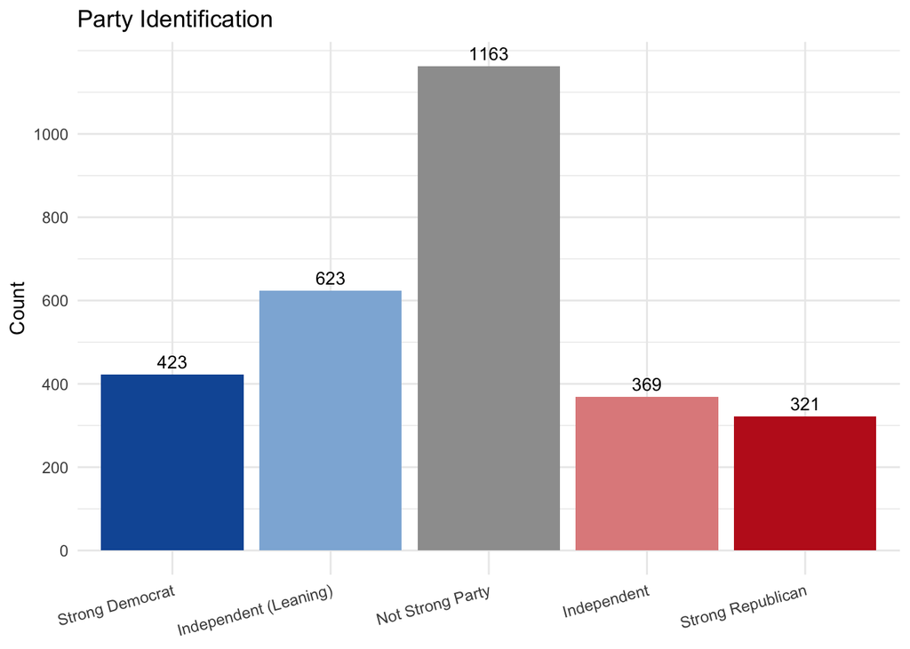

```r
attain_clean |>
  filter(!is.na(party), party != "Other Party") |>
  mutate(party = fct_relevel(
    party,
    "Strong Democrat",
    "Independent (Leaning)",
    "Not Strong Party",       # ambiguous: bundles weak D and weak R
    "Independent",
    "Strong Republican"
  )) |>
  ggplot(aes(x = party, fill = party)) +
  geom_bar() +
  geom_text(
    stat  = "count",
    aes(label = after_stat(count)),
    vjust = -0.5,   # nudge labels just above the top of each bar
    size  = 3.5
  ) +
  scale_fill_manual(values = c(
    "Strong Democrat"       = "#1259A5",
    "Independent (Leaning)" = "#8EB4DA",
    "Not Strong Party"      = "#9E9E9E",
    "Independent"           = "#E08C8C",
    "Strong Republican"     = "#C02020"
  )) +
  scale_y_continuous(breaks = seq(0, 1000, by = 200)) +
  labs(
    title = "Party Identification",
    x     = NULL,
    y     = "Count"
  ) +
  theme_minimal() +
  theme(
    legend.position  = "none",
    axis.text.x      = element_text(angle = 15, hjust = 1)
  )
```

## Create Variables and Rename

This block handles two final cleanup tasks:

1. **`college_years`** — years of education beyond high school. For respondents with 12 or fewer years we assign 0; `NA` values in `educ` propagate as `NA` automatically because no condition is satisfied.
2. **Rename** `marital` to `marital_status` using [`rename()`](https://dplyr.tidyverse.org/reference/rename.html).

```r
attain_clean <- attain_clean |>
  mutate(
    college_years = case_when(
      educ > 12  ~ educ - 12,   # years of schooling beyond a HS diploma
      educ <= 12 ~ 0            # HS diploma or less: set college years to 0
    )) |>
  rename(marital_status = marital) |>  # rename(new_name = old_name)
  glimpse()
```

```
Rows: 2,992
Columns: 14
$ id             <dbl> 1, 2, 3, 4, 5, 6, 7, 8, 9, 10, 11, 12, 13, 14, 15, 16, …
$ marital_status <chr> "divorced", "married", "married", "married", "never ma"…
$ sex            <chr> "female", "male", "female", "male", "female", "female",…
$ race           <chr> "black", "black", "black", "white", "black", "black", "…
$ educ           <dbl> 12, 12, 12, 8, 13, 15, 9, 12, 12, 12, 0, 19, 16, 16, 18…
$ paeduc         <dbl> 12, NA, NA, NA, NA, NA, 12, 8, NA, 6, NA, 14, 0, 12, 19…
$ maeduc         <dbl> 10, 12, NA, 5, 12, 20, NA, 0, 11, 6, 20, 16, 0, 16, 14,…
$ age            <dbl> 33, 59, NA, 59, 21, 22, 40, 25, 41, 45, 52, 31, 55, 56,…
$ partyid        <chr> "strong d", "not str", "ind,near", "not str", "strong d…
$ income91       <dbl> 11250, NA, 16250, 18750, 13750, 45000, 23750, 11250, 27…
$ rincom91       <dbl> NA, NA, 16250, 18750, NA, 11250, 23750, 11250, 18750, 1…
$ educ_cat       <chr> "High School Graduate", "High School Graduate", "High S…
$ party          <chr> "Strong Democrat", "Not Strong Party", "Independent (Le…
$ college_years  <dbl> 0, 0, 0, 0, 1, 3, 0, 0, 0, 0, 0, 7, 4, 4, 6, 4, 6, 4, 0…
```

## Taking a Sample

If your dataset is very large, working with a random sample can speed up iteration during development. If your dataset is really large and it’s taking a long time to load on your computer, you can just use a smaller sample for this class. (Normally, I would not advise doing this, but it is fine for the course). [`slice_sample()`](https://dplyr.tidyverse.org/reference/slice.html) lets you draw either a fixed **number** of rows or a **proportion** of the data. Always call `set.seed()` before sampling so your results are reproducible — anyone running the same code will get the same rows.

```r
# Approach 1: sample a fixed number of rows
set.seed(42)
attain_sample_n <- attain_clean |>
  slice_sample(n = 500)

# Approach 2: sample a proportion of rows (here 10%)
set.seed(42)
attain_sample_prop <- attain_clean |>
  slice_sample(prop = 0.10)

# Compare sizes
nrow(attain_clean)
```

```
[1] 2992
```

```r
nrow(attain_sample_n)
```

```
[1] 500
```

```r
nrow(attain_sample_prop)
```

```
[1] 299
```

For your final project, use the full `attain_clean` — sampling is just shown here as a technique for when datasets are too large to work with comfortably.

## Save the Cleaned Data

Write the cleaned dataset back to `data/` under a new name so the raw file is never overwritten. This is a core principle of reproducible research: always keep the original data untouched.

[`write_csv()`](https://readr.tidyverse.org/reference/write_delim.html) from readr produces a clean, portable CSV with no row numbers.

```r
write_csv(attain_clean, here("data", "attain_clean.csv"))
```

From now on, any analysis script can start with `read_csv(here("data", "attain_clean.csv"))` and skip all the cleaning steps above.

## Data Summary with [`skimr`](https://docs.ropensci.org/skimr/)

[`skim()`](https://docs.ropensci.org/skimr/reference/skim.html) gives a thorough snapshot of the cleaned dataset: counts, missing rates, distributions, and a mini-histogram for each variable. This is a good final check before moving on to analysis.

```r
skim(attain_clean)
```

Data summary

| Name | attain_clean |
| --- | --- |
| Number of rows | 2992 |
| Number of columns | 14 |
| _______________________ |  |
| Column type frequency: |  |
| character | 6 |
| numeric | 8 |
| ________________________ |  |
| Group variables | None |

**Variable type: character**

| skim_variable | n_missing | complete_rate | min | max | empty | n_unique | whitespace |
| --- | --- | --- | --- | --- | --- | --- | --- |
| marital_status | 1 | 1.00 | 7 | 8 | 0 | 5 | 0 |
| sex | 0 | 1.00 | 4 | 6 | 0 | 2 | 0 |
| race | 0 | 1.00 | 5 | 5 | 0 | 3 | 0 |
| partyid | 49 | 0.98 | 7 | 8 | 0 | 6 | 0 |
| educ_cat | 7 | 1.00 | 12 | 21 | 0 | 6 | 0 |
| party | 49 | 0.98 | 11 | 21 | 0 | 6 | 0 |

**Variable type: numeric**

| skim_variable | n_missing | complete_rate | mean | sd | p0 | p25 | p50 | p75 | p100 | hist |
| --- | --- | --- | --- | --- | --- | --- | --- | --- | --- | --- |
| id | 0 | 1.00 | 1496.50 | 863.86 | 1 | 748.75 | 1496.5 | 2244.25 | 2992 | ▇▇▇▇▇ |
| educ | 7 | 1.00 | 13.16 | 2.97 | 0 | 12.00 | 13.0 | 16.00 | 20 | ▁▁▇▇▂ |
| paeduc | 837 | 0.72 | 11.07 | 4.20 | 0 | 8.00 | 12.0 | 14.00 | 20 | ▂▅▇▅▂ |
| maeduc | 432 | 0.86 | 11.08 | 3.46 | 0 | 9.00 | 12.0 | 12.00 | 20 | ▁▃▇▃▁ |
| age | 6 | 1.00 | 45.97 | 17.05 | 18 | 32.25 | 43.0 | 57.00 | 89 | ▆▇▆▃▂ |
| income91 | 356 | 0.88 | 37596.55 | 27456.35 | 500 | 16250.00 | 32500.0 | 55000.00 | 100000 | ▇▇▅▂▂ |
| rincom91 | 1032 | 0.66 | 25852.17 | 20799.05 | 500 | 11250.00 | 21250.0 | 32500.00 | 100000 | ▇▆▂▁▁ |
| college_years | 7 | 1.00 | 1.72 | 2.17 | 0 | 0.00 | 1.0 | 4.00 | 8 | ▇▂▂▁▁ |

## Wrap-Up

In this lab you built a reusable data cleaning pipeline. Key functions covered:

| Task | Function |
| --- | --- |
| Standardize column names | `clean_names()` |
| Subset columns | `select()` |
| Recode categoricals | `case_when()` inside `mutate()` |
| Strip whitespace | `str_trim()` |
| Create derived variables | `mutate()` |
| Rename columns | `rename()` |
| Random sampling | `slice_sample()` |
| Save to disk | `write_csv()` |
| Summarize data | [`skim()`](https://docs.ropensci.org/skimr/) |

**TipBefore You Leave**

- You can explain why we use `here()` instead of a hard-coded file path
- The `educ_cat` and `party` counts look reasonable to you
- `attain_clean.csv` now exists in your `data/` folder
- You understand the difference between `slice_sample(n = ...)` and `slice_sample(prop = ...)`